# Introduction to Idealstan

Robert Kubinec

2018-10-30

*Note: To report bugs with the package, please file an issue on the [Github page](https://github.com/saudiwin/idealstan/issues).*

**If you use this package, please cite the following:**

Kubinec, Robert. “Generalized Ideal Point Models for Time-Varying and Missing-Data Inference”. Working Paper.

This package implements IRT (item response theory) ideal point models, which are models designed for situations in which actors make strategic choices that correlate with a unidimensional scale, such as the left-right axis in American politics, disagreement over product design in consumer choice, or psychometric scales in which the direction that items load on the latent scale is unknown. Compared to traditional IRT, ideal point models examine the polarizing influence of a set of items on a set of persons, and has similarities to models based on Euclidean latent spaces, such as multi-dimensional scaling. In fact, this package also implements a version of the latent space model for binary outcomes, which is an alternate formulation of an ideal point model.

The goal of `idealstan` is to offer a wide variety of ideal point models that can model missing-data, time-varying ideal points, and incorporate a range of outcomes, including binary outcomes, counts, continuous and ordinal responses. In addition, `idealstan` uses the Stan estimation engine to offer full and variational Bayesian inference for all models so that every model is estimated with uncertainty. Variational inference provides a means to estimate Bayesian models on very large data sets when full Bayesian estimation is impractical. The package also exploits variational inference to automatically identify models instead of requiring users to pre-specify which persons or items in the data to constrain in advance.

The approach to handling missing data in this package is to model directly strategic censoring in observations. This particular version was developed to account for legislatures in which legislators (persons) are strategically absent for votes on bills (items), but it applies to any social choice situation in which actors’ failure to respond to an item may be a function of their ideal point. This approach to missing data can be usefully applied to many contexts in which a missing outcome is a function of the person’s ideal point (i.e., people will tend to be present in the data when the item is far away or very close to their ideal point). If missingness does not appear to arise as a function of ideal points, the models will still incorporate missing data but will assume it is essentially random.

The package includes the following models:

1. IRT 2-PL (binary response) ideal point model, no missing-data inflation
2. IRT 2-PL ideal point model (binary response) with missing- inflation
3. Ordinal IRT (rating scale) ideal point model no missing-data inflation
4. Ordinal IRT (rating scale) ideal point model with missing-data inflation
5. Ordinal IRT (graded response) ideal point model no missing-data inflation
6. Ordinal IRT (graded response) ideal point model with missing-data inflation
7. Poisson IRT (Wordfish) ideal point model with no missing data inflation
8. Poisson IRT (Wordfish) ideal point model with missing-data inflation
9. Continuous (Gaussian) IRT ideal point model with no missing data
10. Continuous (Gaussian) IRT ideal point model with missing-data inflation
11. Positive-Continuous (Log-normal) IRT ideal point model with no missing data
12. Positive-Continuous (Log-normal) IRT ideal point model with missing-data inflation
13. Latent Space (binary response) ideal point model with no missing data
14. Latent Space (binary response) ideal point model with missing-data inflation

In addition, all of these models can be estimated with either time-varying or static ideal points if a column of dates for each item is passed to the model function. This package implements the standard time-varying ideal point model by Martin and Quinn (2002) in which ideal points follow a random walk, i.e., in each time period the ideal points can jump in a random direction. In addition, I have implemented a stationary AR(1) ideal point process for situations in which the random walk model does not appropriately reflect over-time change in ideal points. For more information, please see the vignette about time-varying models.

The package also has extensive plotting functions via `ggplot2` for model parameters, particularly the legislator (person) ideal points (ability parameters).

This vignette demonstrates basic usage of the package. I first simulate data using the package, document basic usage and then show an empirical example from the U.S. Senate.

## Simulation of Ordinal IRT with Missing Data

To begin with, we can simulate data from an ordinal ideal-point model in which there are three possible responses corresponding to a legislator voting: yes, abstain and no. An additional category is also simulated that indicates whether a legislator shows up to vote or is absent, which traditional IRT models would record as missing data and would drop from the estimation. This package can instead utilize missing data via a hurdle model in which the censoring of the vote/score data is estimated as a function of individual item/bill intercepts and discrimination parameters for the decision to be absent or present. In other words, if the missing data is a reflection of the person’s ideal point, such as more conservative legislators refusing to show up to vote, than the model will make use of this missing data to infer additional information about the legislators’ ideal points.

The function `id_sim_gen()` allows you to simulate data from any of the fourteen models currently implemented in `idealstan` (see previous list). For example, here we sample data from an ordinal graded response model:

```r
ord_ideal_sim <- id_sim_gen(model='ordinal_grm')
knitr::kable(as_data_frame(head(ord_ideal_sim@score_matrix)))
```

| outcome | item_id | person_id | group_id | time_id |
| --- | --- | --- | --- | --- |
| 1 | 1 | 1 | G | 1 |
| 1 | 1 | 2 | G | 1 |
| 3 | 1 | 3 | G | 1 |
| 3 | 1 | 4 | G | 1 |
| 3 | 1 | 5 | G | 1 |
| 1 | 1 | 6 | G | 1 |

The function `id_estimate` will take this processed data and run an IRT ideal point model. To specify the model type, simply include the number of the model in the `id_estimate` function. The package also includes the ability to incorporate hierarchical (person or item-level) covariates, as discussed below.

The package has options for identification that are similar to other IRT packages in which the IDs of legislators/persons to constrain are specified to the `id_estimate` function. For example, we can use the true values of the simulated legislators to constrain one legislator with the highest simulated ideal point and one legislator with the lowest ideal point. Each constrained parameter must be fixed to a specific value, preferably at either end of the ideal point spectrum, to identify the model. In particular, two pieces of information are necessary: a value for the high ideal point, and the difference between the high and low points. In this example I pre-specify which parameters to constrain and where to pin them based on the simulated data, but the package can also automatically determine these values, which I show in the next section.

```r
true_legis <- ord_ideal_sim@simul_data$true_person
high_leg <- sort(true_legis,decreasing = TRUE,index.return=TRUE)
low_leg <- sort(true_legis,index.return=TRUE)

ord_ideal_est <- id_estimate(idealdata=ord_ideal_sim,
                             model_type=6,
                             fixtype='constrained',
                             id_diff=high_leg$x[1]-low_leg$x[1],
                             id_diff_high=high_leg$x[1],
                             restrict_ind_high = as.character(high_leg$ix[1]),
                             restrict_ind_low=as.character(low_leg$ix[1]),
                             refresh=500,
                             ncores=2,
                             person_sd=1,
                           nchains=2)
```

We can then check and see how well the Stan estimation engine was able to capture the “true” values used in the simulation by plotting the true ideal points relative to the estimated ones:

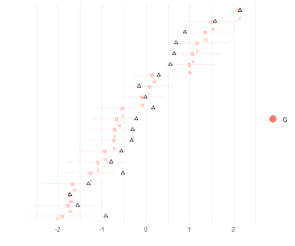

```r
id_plot_legis(ord_ideal_est,show_true = TRUE)
```

Given the small amount of data used to estimate the model, the imprecision with which the ideal points were recovered is not surprising.

To automatically identify the model, simply change the `fixtype` option to `'vb_full'`. By default, the model will select the highest and lowest ideal points to constrain by running an approximation to the full posterior using Stan’s `vb` function. While this method works well, the exact rotation is not known a priori. To specify a rotation of the ideal points while still letting the model decide the optimal placement of the constrained ideal points, set `fixtype` to `'vb_partial'` and include person IDs as a character value for the high constrained ideal point `restrict_ind_high` and low `restrict_ind_low`.

For example, using our simulated data and the default settings (`'vb_full'`):

```r
ord_ideal_est <- id_estimate(idealdata=ord_ideal_sim,
                             model_type=6,
                             refresh=500,
                             ncores=2,
                           nchains=2,
                           person_sd=1)
```

We can see from the plot of the Rhats, which is an MCMC convergence diagnostic, that all the Rhats are below 1.1, which is a good (though not perfect) sign that the model is fully identified:

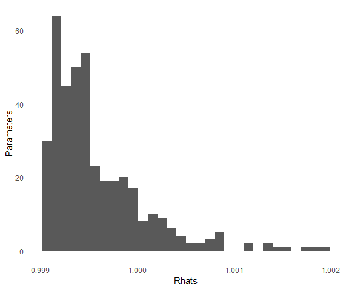

```r
id_plot_rhats(ord_ideal_est)
```

In general, it is always a good idea to check the Rhats before proceeding with further analysis. If the model is not identified even with using `vb_full` as `fixtype`, it is possible to manually change `id_diff` to a larger value to move the ideal points farther apart. However, it is more likely that there is some issue with the data, such as items that do not provide enough variation in the response to identify individual ideal points. Identification of time-varying ideal point models can be more complicated and is discussed in the accompanying vignette.

# Empirical Example: U.S. Senate

This package was developed for datasets that are in a long format, i.e., one row per person/legislator, item/bill, and any other covariate. This data format departs from the traditional way of storing/using IRT/ideal point data, which is more commonly stored in a wide format with legislators/persons in the rows and items/bills in the columns. I have provided a convenience function that can make the necessary transformation for `rollcall` objects from R package `pscl`, but otherwise data should be provided in long form.

We can first take a look at the raw data:

```r
data('senate114')

knitr::kable(select(head(senate114),1:8))
```

| bioname | born | party_code | rollnumber | date | cast_code | congress | chamber |
| --- | --- | --- | --- | --- | --- | --- | --- |
| SESSIONS, Jefferson Beauregard III (Jeff) | 1946 | R | 4 | 2015-01-20 | Yes | 114 | Senate |
| SESSIONS, Jefferson Beauregard III (Jeff) | 1946 | R | 5 | 2015-01-20 | Yes | 114 | Senate |
| SESSIONS, Jefferson Beauregard III (Jeff) | 1946 | R | 7 | 2015-01-21 | Yes | 114 | Senate |
| SESSIONS, Jefferson Beauregard III (Jeff) | 1946 | R | 8 | 2015-01-21 | No | 114 | Senate |
| SESSIONS, Jefferson Beauregard III (Jeff) | 1946 | R | 9 | 2015-01-21 | Yes | 114 | Senate |
| SESSIONS, Jefferson Beauregard III (Jeff) | 1946 | R | 11 | 2015-01-21 | No | 114 | Senate |

```r
table(senate114$cast_code)
```

```
##
##     No    Yes Absent
##  11233  12119    648
```

First, you can see that the data are in long form because there is one row for every vote cast by a legislator, in this case Senator Sessions. The outcome variable is `cast_code`. This variable is coded as a factor variable with the levels in the order we would want for a binary outcome, i.e, `'No'` is before `'Yes'`. Each item in the model is a recorded vote in the Senate, the numbers of which are listed in column `rollnumber`. We also know the dates of the individual items (rollcalls), which we will use in the time-varying ideal point vignette to model time-varying ideal points.

To create an `idealdata` object for modeling from our long data frame, we pass it to the `id_make` function and specify the names of the columns that correspond to person IDs, item IDs, group IDs (i.e., party), time IDs and the outcome, although only person, item and outcome are required for the function to work for a static model.

Because our outcome is discrete and already coded as a factor, we only need to specify the `miss_val` option to tell `id_make` which value of the outcome should be considered as missing data. If the outcome was a different type, such as character or numeric, we would also want to specify the `low_val` and `high_val` options to signify the ordering of the outcomes, whether for ordinal or binary data (for continuous or unbounded outcomes like the Poisson model, only `miss_val` needs to be passed to the function). If there is missing data that we want to ignore, i.e. not model in the function but rather remove before estimation, then we can also pass that value of the data as the `exclude_level` option.

Note that there are many other columns in the `senate114` data. These can be used as person or item/bill covariates, as is discussed at the end of the vignette, but are essentially ignored unless specified to the `id_make` function.

```r
senate_data <- id_make(senate114,outcome = 'cast_code',
                       person_id = 'bioname',
                       item_id = 'rollnumber',
                       group_id= 'party_code',
                       time_id='date',
                       miss_val='Absent')
```

This same missing-data mechanism also applies more broadly to situations of social choice. Any time that missing data might be a function of ideal points–people with certain ideal points are likely to avoid giving an answer–then these values should be marked as `miss_val` in the `id_make` function and an inflated model type should be used.

Because this dataset is relatively large, we will use the `use_vb` option to use Stan’s variational Bayesian inference. This version of the sampler is less accurate and tends to underestimate uncertainty, but it runs much, much faster. Generally speaking, the values of the ideal points are close to the full posterior, and it is useful for exploratory model-building even with small datasets. For very large data, `use_vb` is the only viable option as estimation times may require days or longer.

```r
sen_est <- id_estimate(senate_data,
                model_type = 1,
                 use_vb = T,
                fixtype='vb_partial',
                 restrict_ind_high = "WARREN, Elizabeth",
                 restrict_ind_low="BARRASSO, John A.",
            seed=84520)
```

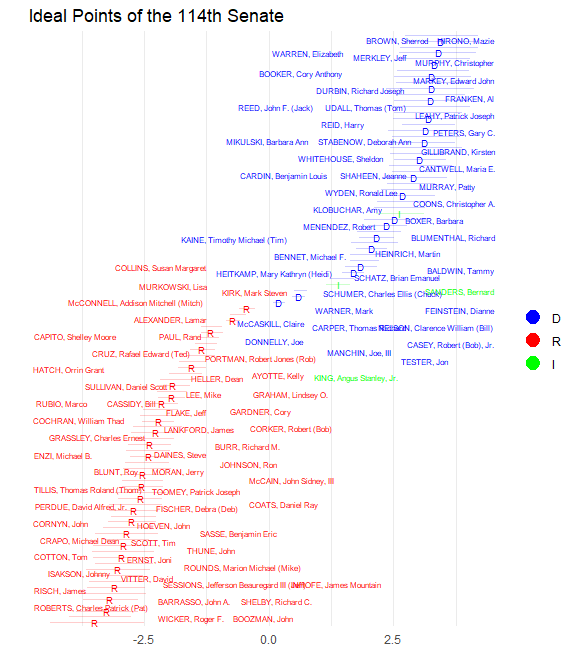

```r
id_plot_legis(sen_est,person_ci_alpha=0.2) +
  scale_color_manual(values=c(D='blue',R='red',I='green')) +
  ggtitle('Ideal Points of the 114th Senate')
```

The `id_plot` function has many other options which are documented in the help files. One notable option, though, is to plot bill midpoints along with the legislator ideal points. The midpoints show the line of equiprobability, i.e., at what ideal point is a legislator with that ideal point indifferent to voting on a bill (or answering an item correctly). To plot a bill midpoint overlay, simply include the character ID of the bill (equivalent to the column name of the bill in the rollcall vote matrix) as the `item_plot` option:

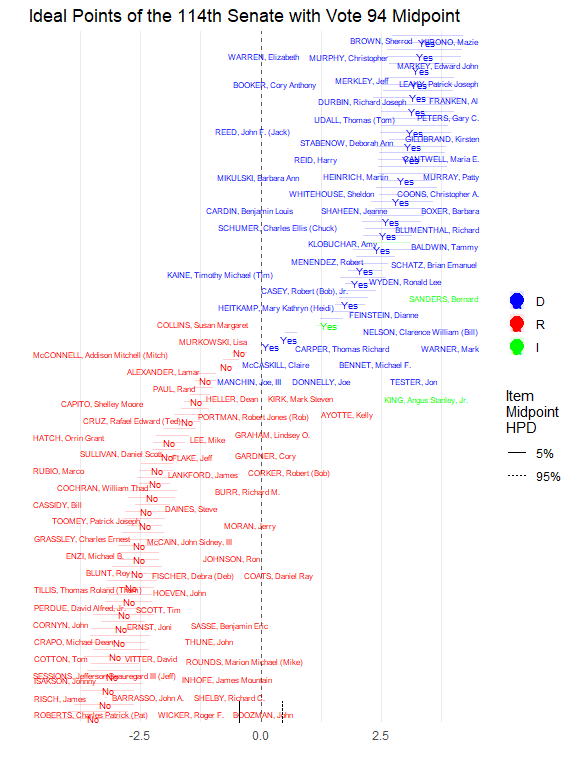

```r
id_plot_legis(sen_est,person_ci_alpha=0.1,item_plot='94') +
  scale_color_manual(values=c(D='blue',R='red',I='green')) +
  ggtitle('Ideal Points of the 114th Senate with Vote 94 Midpoint')
```

To look at the bill’s absence midpoints, simply change the `item_plot_type` parameter to the `id_plot` function:

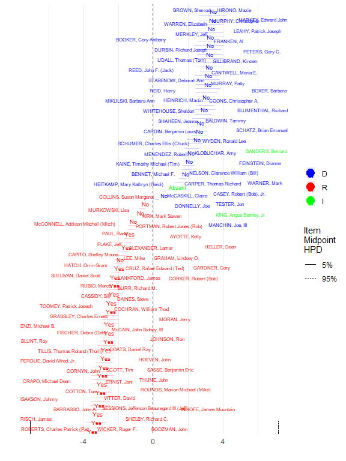

```r
id_plot(sen_est,person_ci_alpha=0.1,item_plot='225',
        item_plot_type='inflated') +
  scale_color_manual(values=c(D='blue',R='red',I='green'))
```

The wide high-posterior density (HPD) interval of the absence midpoint ruglines shows that absences are very uninformative of ideal points for this particular bill (as is common in the Senate where absences are very rare).

## Parameter Values

We can obtain summary estimates of all the ideal points and item/bill discrimination/difficulty parameters using the summary function that provides the median value of the parameters in addition to a specified posterior density interval (i.e., 5%-95%). For example, we can extract summaries for the ideal points:

```r
ideal_pts_sum <- summary(sen_est,pars='ideal_pts')
knitr::kable(head(ideal_pts_sum))
```

| Person | Group | Time_Point | Low Posterior Interval | Posterior Median | High Posterior Interval | Parameter Name |
| --- | --- | --- | --- | --- | --- | --- |
| ALEXANDER, Lamar | R | 1 | -1.580684 | -1.333775 | -1.075193 | L_full[1] |
| BROWN, Sherrod | D | 1 | 2.755809 | 3.447640 | 4.204686 | L_full[10] |
| WARREN, Elizabeth | D | 1 | 3.310694 | 3.328365 | 3.349883 | L_full[100] |
| BURR, Richard M. | R | 1 | -2.531969 | -2.199000 | -1.890465 | L_full[11] |
| CANTWELL, Maria E. | D | 1 | 2.489545 | 3.206960 | 3.961533 | L_full[12] |
| CAPITO, Shelley Moore | R | 1 | -2.234487 | -1.911130 | -1.574654 | L_full[13] |

`Parameter Name` is the name of the parameter in the underlying Stan code, which can be useful f you want to peruse the fitted Stan model (and can be accessed as given in the code below). The name of the parameters for ideal points in the Stan model is `L_full` (as seen in the summary from above).

```r
stan_obj <- sen_est@stan_samples
# show the
print(stan_obj,pars = c("L_full[1]",
                        'L_full[2]',
                        'L_full[3]'))
```

```
## Inference for Stan model: irt_standard.
## 1 chains, each with iter=1000; warmup=0; thin=1;
## post-warmup draws per chain=1000, total post-warmup draws=1000.
##
##            mean   sd  2.5%   25%   50%   75% 97.5%
## L_full[1] -1.33 0.15 -1.63 -1.44 -1.33 -1.23 -1.05
## L_full[2] -0.72 0.09 -0.88 -0.78 -0.72 -0.66 -0.54
## L_full[3]  2.92 0.39  2.21  2.65  2.92  3.17  3.71
##
## Approximate samples were drawn using VB(meanfield) at Tue Oct 30 17:23:58 2018.
```

```
## We recommend genuine 'sampling' from the posterior distribution for final inferences!
```

If we know the name of the Stan parameter, we can look at the trace plot to see how the quality of the Markov Chain Monte Carlo (MCMC) sampling used to fit the model. A good trace plot shows a bouncy line that is stable around an average value. For more info, see the [Stan documentation](http://mc-stan.org/users/documentation/case-studies/rstan_workflow.html).

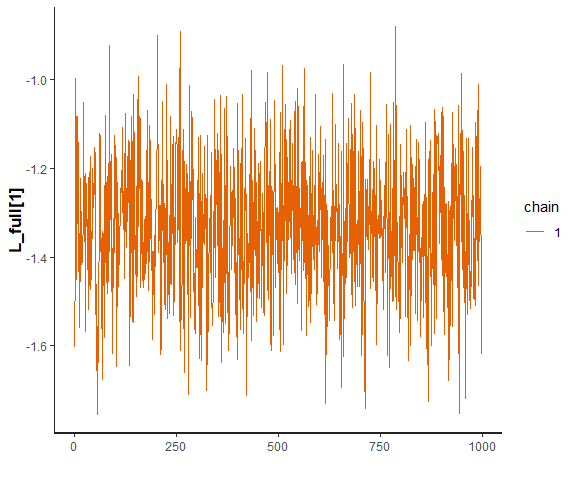

```r
stan_trace(sen_est,par='L_full[1]')
```

Finally we can also extract all of the posterior iterations to do additional calculations that average over posterior uncertainty by changing the `aggregate` option in `summary`. In the following code, I access the individual posterior iterations for the item/bill parameters, including difficulty (average probability of voting yes), discrimination (how strongly the item/bill loads on either end of the ideal point scale) and the midpoints (position where someone with that ideal point would be indifferent to voting yes/no).

```r
item_all <- summary(sen_est,pars='items', aggregate=F)
knitr::kable(head(item_all))
```

| Posterior_Sample | Item Name | Item Type | Predicted Outcome | Parameter | Iteration |
| --- | --- | --- | --- | --- | --- |
| 0.4673904 | 4 | Non-Inflated Item Midpoint | Yes | A function of other parameters | 1 |
| 0.8389473 | 4 | Non-Inflated Item Midpoint | Yes | A function of other parameters | 2 |
| 0.0692189 | 4 | Non-Inflated Item Midpoint | Yes | A function of other parameters | 3 |
| 1.1488926 | 4 | Non-Inflated Item Midpoint | Yes | A function of other parameters | 4 |
| 0.6884007 | 4 | Non-Inflated Item Midpoint | Yes | A function of other parameters | 5 |
| 0.3820758 | 4 | Non-Inflated Item Midpoint | Yes | A function of other parameters | 6 |

## Hierarchical Covariates

Finally, we can also fit a model where we include a covariate that varies by person/legislator. To do so, we need to pass a one-sided formula to the `id_make` function to prepare the data accordingly. By way of example, we will include a model where we include an interaction between party ID (`party_code`) and the legislator’s age to see if younger/older legislators are more or less conservative.

**It is important to note that for static ideal point models, covariates are only defined over the legislators/persons who are not being used as constraints in the model, such as John Barasso and Elizabeth Warren in this model.**

```r
senate114$age <- 2018 - senate114$born

senate_data <- id_make(senate114,outcome = 'cast_code',
                       person_id = 'bioname',
                       item_id = 'rollnumber',
                       group_id= 'party_code',
                       time_id='date',
                       person_cov = ~party_code*age,
                       miss_val='Absent')

sen_est_cov <- id_estimate(senate_data,
                model_type = 1,
                 use_vb = T,
                fixtype='vb_full',
                 restrict_ind_high = "BARRASSO, John A.",
                 restrict_ind_low="WARREN, Elizabeth",
            seed=84520)
```

We can then look at a plot of the covariate values:

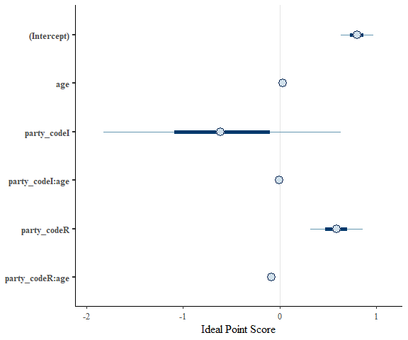

```r
id_plot_cov(sen_est_cov,cov_type='person_cov')
```

Because of the scale of the plot, it can be difficult to see the values for the age interaction. However, because the plot is a `ggplot` object, we can restrict the x axis:

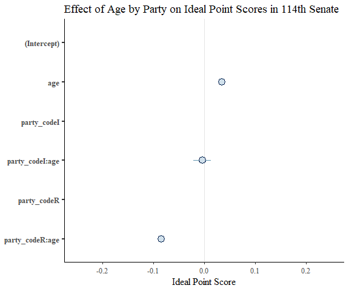

```r
id_plot_cov(sen_est_cov,cov_type='person_cov') + xlim(c(-0.25,0.25)) +
  ggtitle('Effect of Age by Party on Ideal Point Scores in 114th Senate')
```

Or we can filter which parameters we want to include in the plot:

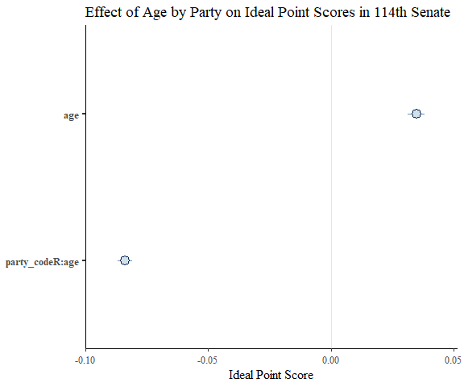

```r
id_plot_cov(sen_est_cov,cov_type='person_cov',
            filter_cov=c('age','party_codeR:age')) +
  ggtitle('Effect of Age by Party on Ideal Point Scores in 114th Senate')
```

And we can use `ggplot2` scale functions to change the labels on the plot for the y axis:

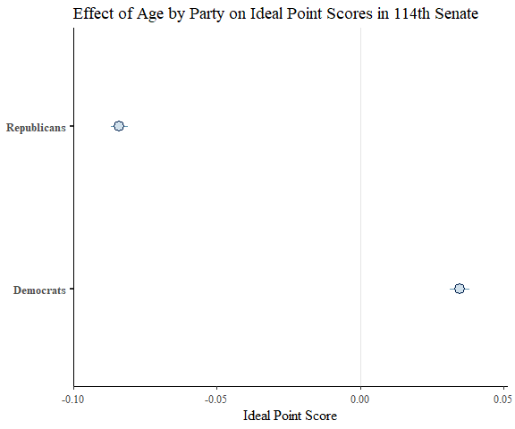

```r
id_plot_cov(sen_est_cov,cov_type='person_cov',
            filter_cov=c('age','party_codeR:age')) +
  ggtitle('Effect of Age by Party on Ideal Point Scores in 114th Senate') +
  scale_y_discrete(breaks=c('age','party_codeR:age'),
                   labels=c('Democrats','Republicans'))
```

Because these covariates are on the ideal point scale, the meaning of the scale in terms of party ideology must be kept in mind in order to interpret the plot. First, because we only have estimates for the “I” and “R” values of `party_code`, we know that the Democrats “D” are being used as the reference value. As a consequence, the coefficient for `age` is equal to the effect of age for Democrats (i.e., when the person is neither Republican or Independent). As a result, a negative value for age for Democrats corresponds to more liberalism as they are on the negative side of the scale, while a positive value for age for Republicans implies more conservatism (and vice versa). Keeping the direction of the scale in mind is crucial for understanding hierarchical covariates in ideal point models.

Of course, because this model was fit with variational inference (`use_vb=T`), the results are an approximation. It would be good to run full Bayesian inference to obtain final estimates.

We can also extract the covariate summary values using the `summary` function:

```r
cov_sum <- summary(sen_est_cov,pars='person_cov')
knitr::kable(cov_sum)
```

| Covariate | Posterior Median | Posterior High Interval | Posterior Low Interval | Parameter |
| --- | --- | --- | --- | --- |
| (Intercept) | 0.8019915 | 0.9727389 | 0.6298487 | legis_x |
| age | 0.0348486 | 0.0382711 | 0.0312884 | legis_x |
| party_codeI | -0.6157650 | 0.6317222 | -1.8240845 | legis_x |
| party_codeI:age | -0.0035973 | 0.0130968 | -0.0207881 | legis_x |
| party_codeR | 0.5891285 | 0.8586591 | 0.3194448 | legis_x |
| party_codeR:age | -0.0840623 | -0.0809535 | -0.0869863 | legis_x |